# DATA 607 Final Project: Predicting Financial Well Being

David Simbandumwe

# Overview

Financial wellness can be defined in many different ways for purposes of this analysis Financial wellness is your relationship with money. It refers to how secure your money is, given all the variables involving an unknown future. [*Financial Education Council*](https://www.financialeducatorscouncil.org/financial-wellness-definition/).

This is a broad definition but it includes several key concepts including:

- preparation for emergencies
- active short term and long term plans and goals
- budgeting and attitudes towards money
- how do your finances make you feel

Intuitively we understand the importance of financial wellness to an individuals immediate financial stability, their long-term aggregation of wealth and financial sustainability in retirement. Making good financial decisions to optimize your current economic position, build wealth and ensure long-term economic stability. These benefits are well documented, studied and highlighted by financial advisers and wealth management firms. However the impact of financial wellness on your emotional and mental health should not be ignored our understated. The stress, anxiety, depression, sleep deprivation or even lack of motivation that comes with poorly handled money matters will impact all aspects of your life.

When people are in control of their money, they’re in control of their lives. They’re happier, less anxious and more empowered. [*nudge*](https://www.nudge-global.com)

Few topics will have such a large impact on you current and future life (stressor, determinant of economic). Not just from an economic perspective but also from a emotional health and mental health. The only solution is to introduce concepts such as financial knowledge, introducing concepts such as debt management, planning, and other financially relevant topics. This will however not be enough, taking a step further to help implement these concepts in their financial habits and put them on the right track towards wellness.

I have been interested in measure and predictors of financial wellness for several years now. Financial knowledge is critical for individuals however there are enormous discrepancies in who develops financial literacy and who does not. Key to understanding how to develop it is how to measure it and what factor impact financial wellness. The goal of this project is to explore the measurements of financial wellness and the factors that determine it. This is my third data science class and i would like to explore the data science modeling landscape.

The main goal is to explore several modeling packages and build a set of predictive models across the two data sets. The use of two data sets that share a common measure of financial well being should provide an opportunity to explore modeling process from a few different vantage points.

## Data Sources:

There are numerous studies of financial wellness sponsored by financial firms, industry groups and government agencies. I choose to focus on two studies:

- Consumer Financial Protection Bureau - Financial Wellness Survey [*Financial well-being data*](https://www.consumerfinance.gov/data-research/financial-well-being-survey-data/) The PUF survey results can be accessed as a csv file [*Financial well-being survey data*](https://www.consumerfinance.gov/documents/5614/NFWBS_PUF_2016_data.csv)
- Federal Reserve System - Survey of Household Economic and Decision making [*Federal Reserve Household Economic Decisions*](https://www.federalreserve.gov/consumerscommunities/shed_data.htm) The SHED survey results can be accessed as a zip file *Survey of Household Economics and Decisionmaking 2020*

These are comprehensive studies that are conducted periodicaly using similar methodology. Both studies survey the population to gather demographic, financial and behavioral data from individuals. Both studies include the same measure of financial well being that was defined and operationalized by the Consumer Financial Protection Bureau called the Financial Well-Being Scale. The Financial Well-Being Scale was created as part of the Consumer Financial Protection Bureau to encourage Financial Wellness.

The score is calcuated using 10 questions survey:

**How well does this statement describe you or your situation?**

1. I could handle a major unexpected expense
2. I am securing my financial future
3. Because of my money situation, I feel like I will never have the things I want in life*
4. I can enjoy life because of the way I’m managing my money
5. I am just getting by financially
6. I am concerned that the money I have or will save won’t last

**How often does this statement apply to you?**

7. Giving a gift for a wedding, birthday or other occasion would put a strain on my finances for the month*
8. I have money left over at the end of the month
9. I am behind with my finances
10. My finances control my life

### Consumer Financial Protection Bureau - Financial Wellness Survey

The data was collected as part of the Consumer Financial Protection Bureau’s (CFPB) National Financial Well-Being Survey Public Use File (PUF). The PUF is a dataset containing

1. demographic data
2. assessment of financial knowledge
3. financial positions
4. financial products owned
5. financial well-being scale

The National Financial Well-Being Survey was conducted in English and Spanish via web mode between October 27, 2016 and December 5, 2016. Overall, 6,394 surveys were completed: 5,395 from the general population sample and 999 from an oversample of adults aged 62 and older. The survey was designed to represent the adult population of the 50 U.S. states and the District of Columbia. The survey was fielded on the GfK KnowledgePanel®. The KnowledgePanel sample is recruited using address-based sampling and dual-frame landline and cell phone random digit dialing methods.

The PUF was published in 2017.

### Federal Reserve System - Survey of Household Economic and Decision making (SHED)

The data was collected as part of the Report on the Economic Well‐Being of U.S. Households in 2020,and examines the economic well-being and financial lives of U.S. adults and their families.

Federal Reserve Board. The SHED includes:

1. demographic data
2. assessment of financial knowledge
3. financial products owned
4. financial positions
5. economic fragility
6. financial well-being scale

The SHED is sponsored by the Board of Governors of the Federal Reserve System. The surveys that generate the data are collected by Ipsos using their online probability based KnowledgePanel. The 2020 survey of more than 11,000 adults was conducted in November 2020, offering a picture of how people were faring eight months after the onset of the COVID-19 pandemic.

The SHED was published in 2020.

## Setup

setup environment for analysis

```r
set.seed(1234)
rm(list=ls())
```

Exported data load, tidy function and tibble cleaning

```r
fun_file_name <- glue(getwd(), "/ProjectFinal/DATA607_Functions.R")
source(fun_file_name, local = knitr::knit_global())
```

## Workflow

This project is based on the OSEMN analysis Model.

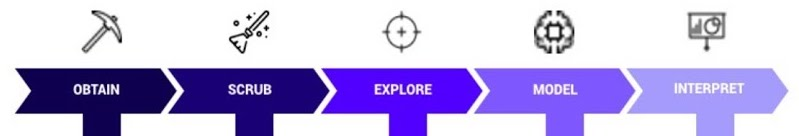

OSEMN analysis Model

# Obtain

The data for the analysis was abtained from the following sources:

- Consumer Financial Protection Bureau - Financial Wellness Survey: The PUF survey results can be accessed as a csv file [*Financial well-being survey data*](https://www.consumerfinance.gov/documents/5614/NFWBS_PUF_2016_data.csv)
- Federal Reserve System - Survey of Household Economic and Decision making: The SHED survey results can be accesssed as a zip file *Survey of Household Economics and Decisionmaking 2020*

```r
cfpbRaw_df <- getRawCFPBFile()
fedRaw_df <- getRawFedFile()


s_df <- tibble("name"=character(), "vars"=double(), "obs"=double(), "cfpb_mean"=double(), "cfpb_median"=double(), "cfpb_std"=double() )
s_df <- s_df %>% add_row(name="cfpb", vars=ncol(cfpbRaw_df) ,obs=nrow(cfpbRaw_df), cfpb_mean=round(mean(cfpbRaw_df$FWBscore),2),
                 cfpb_median=round(median(cfpbRaw_df$FWBscore),2), cfpb_std=round(sd(cfpbRaw_df$FWBscore),2))
s_df <- s_df %>% add_row(name="fed", vars=ncol(fedRaw_df) ,obs=nrow(fedRaw_df), cfpb_mean=round(mean(fedRaw_df$CFPB_score),2),
                 cfpb_median=round(median(fedRaw_df$CFPB_score),2), cfpb_std=round(sd(fedRaw_df$CFPB_score),2) )

s_df %>%
  kbl() %>%
  column_spec(1, bold = T, border_right = T) %>%
  kable_paper(bootstrap_options = "striped", fixed_thead = T,full_width = F)
```

| name | vars | obs | cfpb_mean | cfpb_median | cfpb_std |
| --- | --- | --- | --- | --- | --- |
| cfpb | 217 | 6394 | 56.03 | 56 | 14.15 |
| fed | 372 | 11648 | 56.32 | 55 | 14.85 |

```r
#cfpb
#names(cfpbRaw_df)

#fed
#names(fedRaw_df)
```

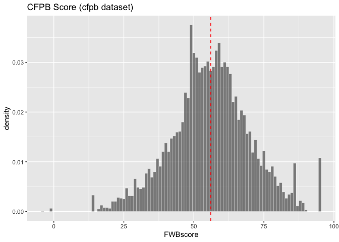

```r
# cfpb
ggplot(cfpbRaw_df,
    aes(FWBscore, y = stat(density))) +
    geom_histogram(binwidth = 1, alpha = 0.7, bins = 100, color="white",size = 0.1) +
    geom_vline(aes(xintercept = mean(FWBscore)), linetype = "dashed", color="red", size = 0.5) +
    scale_fill_brewer(palette="Spectral") +
    labs(title = "CFPB Score (cfpb dataset)")
```

```r
summary(cfpbRaw_df$FWBscore)
```

```
##    Min. 1st Qu.  Median    Mean 3rd Qu.    Max.
##   -4.00   48.00   56.00   56.03   65.00   95.00
```

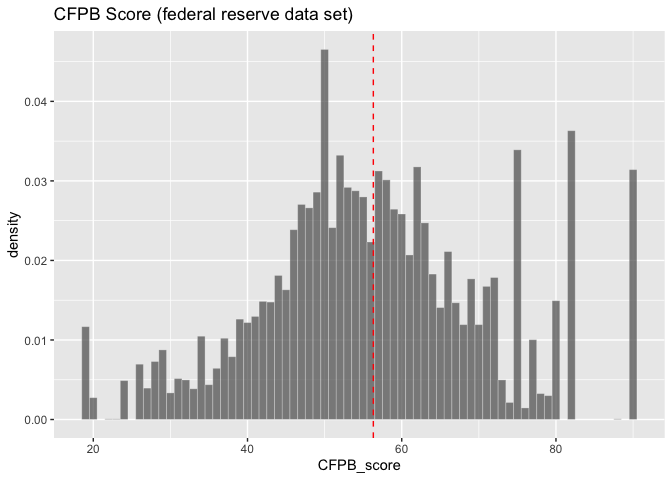

```r
# fed
ggplot(fedRaw_df,
    aes(CFPB_score, y = stat(density))) +
    geom_histogram(binwidth = 1, alpha = 0.7, bins = 100, color="white",size = 0.1) +
    geom_vline(aes(xintercept = mean(CFPB_score)), linetype = "dashed", color="red", size = 0.5) +
    scale_fill_brewer(palette="Spectral") +
    labs(title = "CFPB Score (federal reserve data set)")
```

```r
summary(fedRaw_df$CFPB_score)
```

```
##    Min. 1st Qu.  Median    Mean 3rd Qu.    Max.
##   19.00   47.00   55.00   56.32   66.00   90.00
```

**observations**

- Fin Well Scaled score has consistent stats across both surveys
- Survey’s are comprehensive so I will need to identify a managable set of variable and observations to support the analysis
- Most of the variables are categorical
- cfpb survey data is coded based on the survey responses. To be usable the data can be converted to factor variables that capture the survey code and the definition
- survey response data requires the code book to disifer the variables in the file.

# Scrub

The scrub step in the process leverages the two code books for the survey to filter, translate and rename the variables.

```r
# get cfpb file
cfpb_df <- getCFPBFile()
```

```r
cfpb_df$cfpb_score_4cat <- cut(cfpb_df$cfpb_score, breaks = c(-10, 40, 60, 80, 100),
                           labels = c("< 40","40-60","60-80","80-100"),
                           right = FALSE,
                           include.lowest=TRUE)
s_df <- tibble("cfpb" = levels(count(cfpb_df$cfpb_score_4cat)$x))
s_df <- add_column(s_df,"cfpb_freq" = count(cfpb_df$cfpb_score_4cat)$freq)
cfpb_df <- cfpb_df %>% filter(cfpb_score >= 0)

# reduce cfpb dataset
cfpb_df <- slice_sample(cfpb_df, weight_by=cfpb_score_4cat ,n=4000)
s_df <- add_column(s_df,"cfpb_filter" = levels(count(cfpb_df$cfpb_score_4cat)$x))
s_df <- add_column(s_df,"cfpb_filter_freq" = count(cfpb_df$cfpb_score_4cat)$freq)


# get fed file
fed_df <- getFedFile()
fed_df$cfpb_score_4cat <- cut(fed_df$cfpb_score, breaks = c(-10, 40, 60, 80, 100),
                           labels = c("< 40","40-60","60-80","80-100"),
                           right = FALSE,
                           include.lowest=TRUE)
s_df <- add_column(s_df,"fed" = levels(count(fed_df$cfpb_score_4cat)$x))
s_df <- add_column(s_df,"fed_freq" = count(fed_df$cfpb_score_4cat)$freq)

# reduce cfpb dataset
fed_df <- slice_sample(fed_df, weight_by=cfpb_score_4cat ,n=4000)
s_df <- add_column(s_df,"fed_filter" = levels(count(fed_df$cfpb_score_4cat)$x))
s_df <- add_column(s_df,"fed_filter_freq" = count(fed_df$cfpb_score_4cat)$freq)


# a1 <- fedRaw_df
# count(a1$ED0)
# a1 <- purrr::modify_if(a1, is.character ,iconv ,"latin1", "UTF-8",sub='')
# a1 <- purrr::modify_if(a1, is.character,str_trunc , 40)
#
# fed_df$ED0 <- iconv(fed_df$ED0, "latin1", "UTF-8",sub='')
# fed_df$ED0 <- str_trunc(fed_df$ED0,40)
#
#
# ?purrr::modify_if()
```

```r
s_df   %>% kbl() %>%
  kable_paper(bootstrap_options = "striped", fixed_thead = T,full_width = F)
```

| cfpb | cfpb_freq | cfpb_filter | cfpb_filter_freq | fed | fed_freq | fed_filter | fed_filter_freq |
| --- | --- | --- | --- | --- | --- | --- | --- |
| < 40 | 733 | < 40 | 273 | < 40 | 1349 | < 40 | 230 |
| 40-60 | 3152 | 40-60 | 1849 | 40-60 | 5769 | 40-60 | 1775 |
| 60-80 | 2186 | 60-80 | 1599 | 60-80 | 3566 | 60-80 | 1504 |
| 80-100 | 323 | 80-100 | 279 | 80-100 | 964 | 80-100 | 491 |

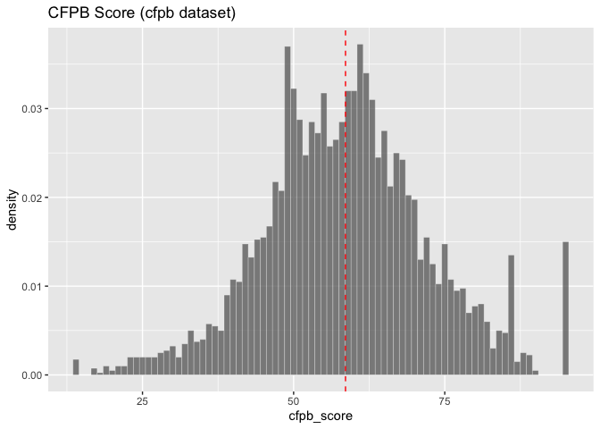

```r
# cfpb
ggplot(cfpb_df,
    aes(cfpb_score, y = stat(density))) +
    geom_histogram(binwidth = 1, alpha = 0.7, bins = 100, color="white",size = 0.1) +
    geom_vline(aes(xintercept = mean(cfpb_score)), linetype = "dashed", color="red", size = 0.5) +
    scale_fill_brewer(palette="Spectral") +
    labs(title = "CFPB Score (cfpb dataset)")
```

```r
summary(cfpb_df$cfpb_score)
```

```
##    Min. 1st Qu.  Median    Mean 3rd Qu.    Max.
##   14.00   50.00   59.00   58.58   67.00   95.00
```

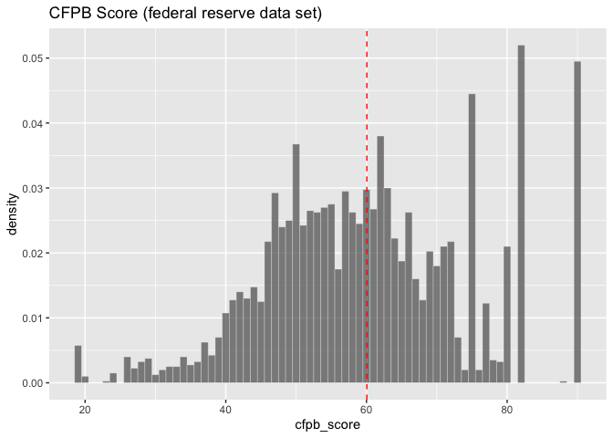

```r
# fed
ggplot(fed_df,
    aes(cfpb_score, y = stat(density))) +
    geom_histogram(binwidth = 1, alpha = 0.7, bins = 100, color="white",size = 0.1) +
    geom_vline(aes(xintercept = mean(cfpb_score)), linetype = "dashed", color="red", size = 0.5) +
    scale_fill_brewer(palette="Spectral") +
    labs(title = "CFPB Score (federal reserve data set)")
```

```r
summary(fed_df$cfpb_score)
```

```
##    Min. 1st Qu.  Median    Mean 3rd Qu.    Max.
##   19.00   50.00   59.00   60.05   70.00   90.00
```

**observations**

- outliers - the data includes outlier score below 20 and above 90. Since this distribution is likely a reflection of the population these records were retained in the data set.

# Explore

After reducing the survey data to smaller manageable set of observations and variables we can explore the details of the data set using the summary function.

The model depends on the following conditions 1. residuals are nearly normal (less important for larger data sets) 2. residuals have constant variability 3. residuals are independent 4. each variable is linearly related to the outcome

## Consumer Financial Protection Bureau

**Observations**

- decline or refuse to answer are included in the survey results. It might be interesting to filter out all of these respondants.

**Identified the following categories of data**

```r
cfpb_tmp_df <- cfpb_df %>% select(cfpb_score, econ_hh_income, econ_save_rate, age_8cat)
summary(cfpb_tmp_df)
```

```
##    cfpb_score                 econ_hh_income           econ_save_rate
##  Min.   :14.00   $100,000 to $149,999:719    $5,000-19,999    :708
##  1st Qu.:50.00   $75,000 to $99,999  :612    Prefer not to say:633
##  Median :59.00   $150,000 or more    :599    $75,000 or more  :609
##  Mean   :58.58   $60,000 to $74,999  :423    $1,000-4,999     :567
##  3rd Qu.:67.00   Less than $20,000   :371    $20,000-74,999   :564
##  Max.   :95.00   $30,000 to $39,999  :358    $100-999         :397
##                  (Other)             :918    (Other)          :522
##     age_8cat
##  62-69  :684
##  25-34  :671
##  45-54  :656
##  75+    :493
##  35-44  :465
##  55-61  :460
##  (Other):571
```

**Observations**

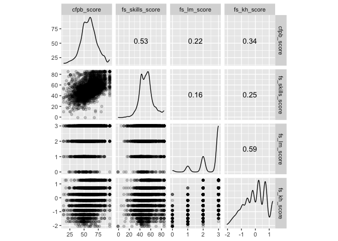

```r
ggscatmat(data=cfpb_df, corMethod = "spearman", alpha=0.2)
```

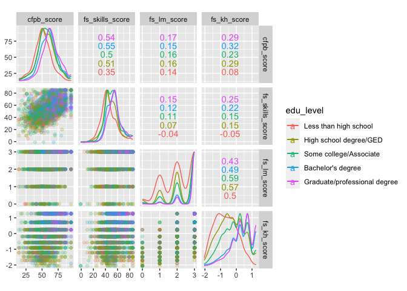

```r
ggscatmat(data=cfpb_df, color="edu_level", corMethod = "spearman", alpha=0.2)
```

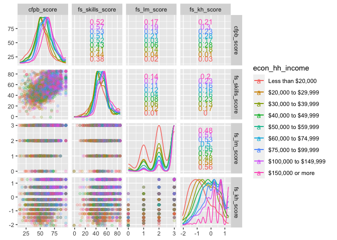

```r
ggscatmat(data=cfpb_df, color="econ_hh_income", corMethod = "spearman", alpha=0.2)
```

**explore specific variables**

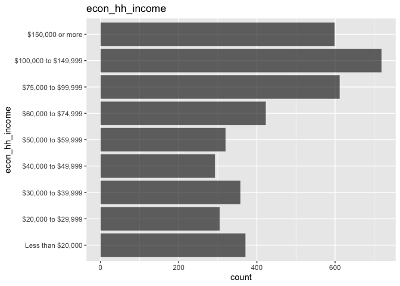

```r
# econ_hh_income
ggplot(cfpb_df, aes(x=econ_hh_income)) +
  geom_bar(color="white", fill="black", alpha = 0.6, size = 0.1) +
  coord_flip() +
  labs(title = "econ_hh_income")
```

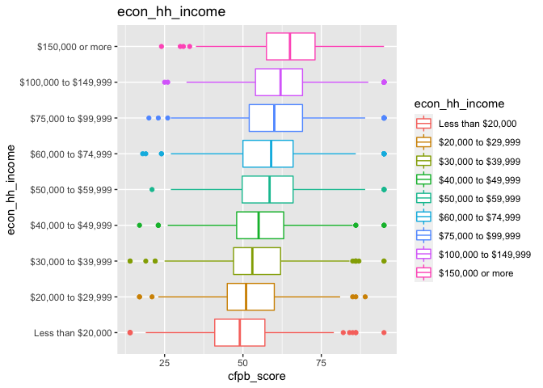

```r
ggplot(data = cfpb_df) +
  geom_boxplot(mapping = aes(x=cfpb_score, y=econ_hh_income, color=econ_hh_income)) +
  labs (title = "econ_hh_income")
```

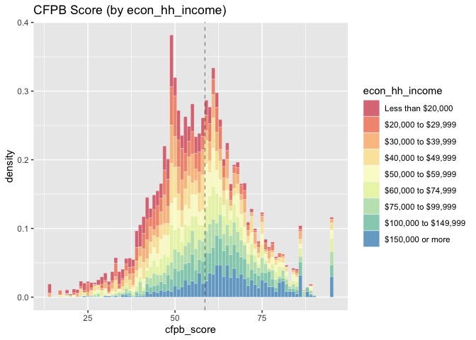

```r
ggplot(cfpb_df,
    aes(cfpb_score, fill = econ_hh_income, y = stat(density))) +
    geom_histogram(binwidth = 1, alpha = 0.7, bins = 100, color="white",size = 0.1) +
    geom_vline(aes(xintercept = mean(cfpb_score)), linetype = "dashed", size = 0.2) +
    scale_fill_brewer(palette="Spectral") +
    labs(title = "CFPB Score (by econ_hh_income)")
```

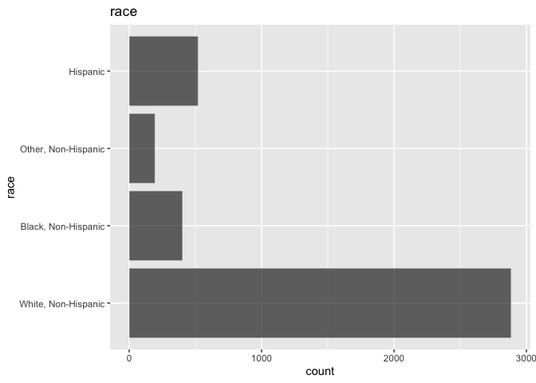

```r
# race
ggplot(cfpb_df, aes(x=race)) +
  geom_bar(color="white", fill="black", alpha = 0.6, size = 0.1) +
  coord_flip() +
  labs(title = "race")
```

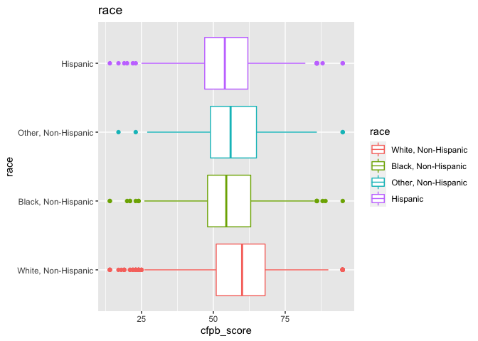

```r
ggplot(data = cfpb_df) +
  geom_boxplot(mapping = aes(x=cfpb_score, y=race, color=race)) +
  labs (title = "race")
```

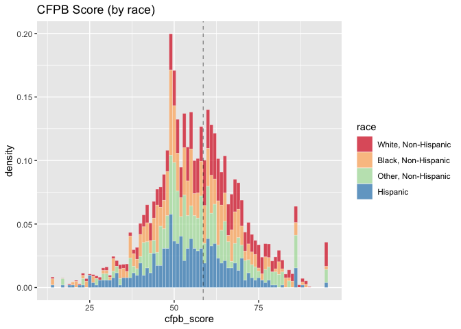

```r
ggplot(cfpb_df,
    aes(cfpb_score, fill = race, y = stat(density))) +
    geom_histogram(binwidth = 1, alpha = 0.7, bins = 100, color="white",size = 0.1) +
    geom_vline(aes(xintercept = mean(cfpb_score)), linetype = "dashed", size = 0.2) +
    scale_fill_brewer(palette="Spectral") +
    labs(title = "CFPB Score (by race)")
```

## Federal Reserve System

**Observations**

- related variables - the federal reserve data set includes sveral classifications of the same variable (income, age, house hold composition, race). A full analysis would include identifying the best representation for each of these categories. For the purposes of this project ia m including all the variables understanding that there is more analysis necessary.
- survey data includes non complete records - the second phase of the analysis would be to identify smaller subset of the variable and review the impact of incomplete data sets and outliers.

**Identified the following categories of data**

- demographic data - including gender, race, marital status
- employment
- household composition
- education - including mother and father education
- economic situation - household ownership, economic circumstances

```r
#fed_tmp_df <- fed_df %>% select(cfpb_score, econ_saving, econ_fin_ok, econ_pay_exp400, econ_skip_med, edu, credit_guess)
fed_tmp_df <- fed_df %>% select(cfpb_score, age, age_7cat, econ_saving, econ_inc_4cat, econ_fin_ok, econ_pay_exp400, econ_skip_med) #0.4675

summary(fed_tmp_df)
```

```
##    cfpb_score         age         age_7cat                econ_saving
##  Min.   :19.00   Min.   :18.00   18-24:252   Under $50,000      :1175
##  1st Qu.:50.00   1st Qu.:36.00   25-34:646                      : 796
##  Median :59.00   Median :55.00   35-44:557   $100,000 - $249,999: 455
##  Mean   :60.05   Mean   :52.07   45-54:528   $50,000 - $99,999  : 392
##  3rd Qu.:70.00   3rd Qu.:66.00   55-64:845   $1,000,000 or more : 339
##  Max.   :90.00   Max.   :94.00   65-74:786   $250,000 - $499,999: 335
##                                  75+  :386   (Other)            : 508
##            econ_inc_4cat   econ_fin_ok   econ_pay_exp400 econ_skip_med
##  $100,000 or more :1419   No     : 669   No     :1001    No     :3272
##  $25,000-$49,999  : 671   Refused:   4   Refused:  22    Refused:  20
##  $50,000-$99,999  :1061   Yes    :3327   Yes    :2977    Yes    : 708
##  Less than $25,000: 810
##  Refused          :  39
##
##
```

**Observations**

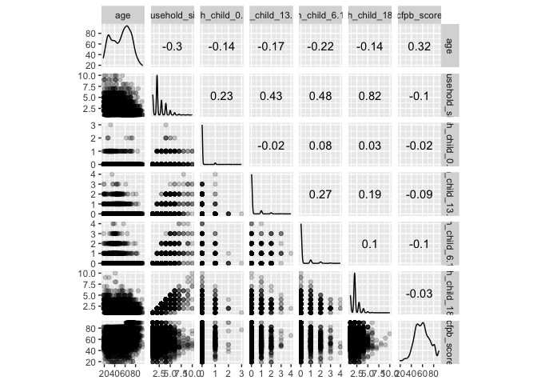

```r
ggscatmat(data=fed_df, corMethod = "spearman", alpha=0.2)
```

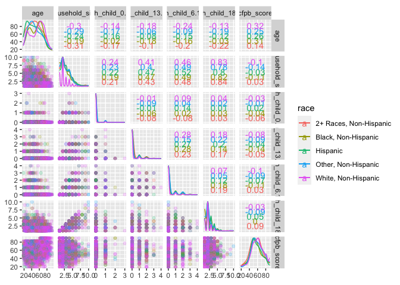

```r
ggscatmat(data=fed_df, color="race", corMethod = "spearman", alpha=0.2)
```

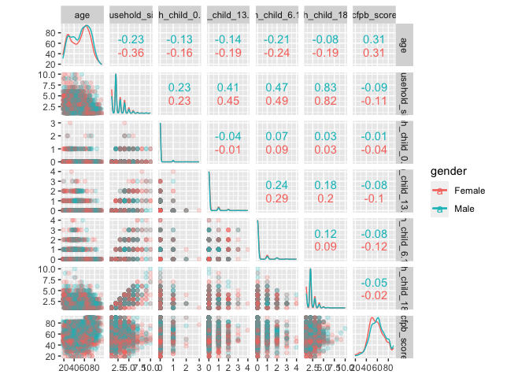

```r
ggscatmat(data=fed_df, color="gender", corMethod = "spearman", alpha=0.2)
```

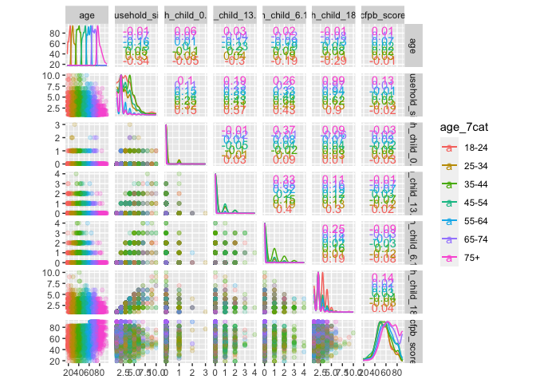

```r
ggscatmat(data=fed_df, color="age_7cat", corMethod = "spearman", alpha=0.2)
```

**explore specific variables**

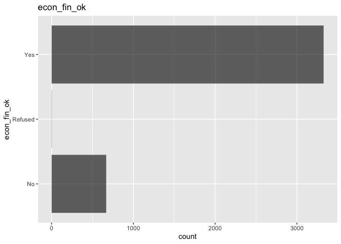

```r
# econ_fin_ok
ggplot(fed_df, aes(x=econ_fin_ok)) +
  geom_bar(color="white", fill="black", alpha = 0.6, size = 0.1) +
  coord_flip() +
  labs(title = "econ_fin_ok")
```

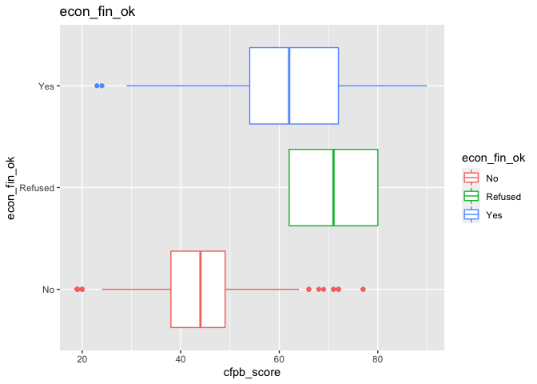

```r
ggplot(data = fed_df) +
  geom_boxplot(mapping = aes(x=cfpb_score, y=econ_fin_ok, color=econ_fin_ok)) +
  labs (title = "econ_fin_ok")
```

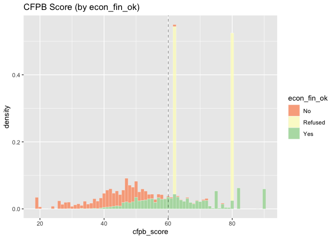

```r
ggplot(fed_df,
    aes(cfpb_score, fill = econ_fin_ok, y = stat(density))) +
    geom_histogram(binwidth = 1, alpha = 0.7, bins = 100, color="white",size = 0.1) +
    geom_vline(aes(xintercept = mean(cfpb_score)), linetype = "dashed", size = 0.2) +
    scale_fill_brewer(palette="Spectral") +
    labs(title = "CFPB Score (by econ_fin_ok)")
```

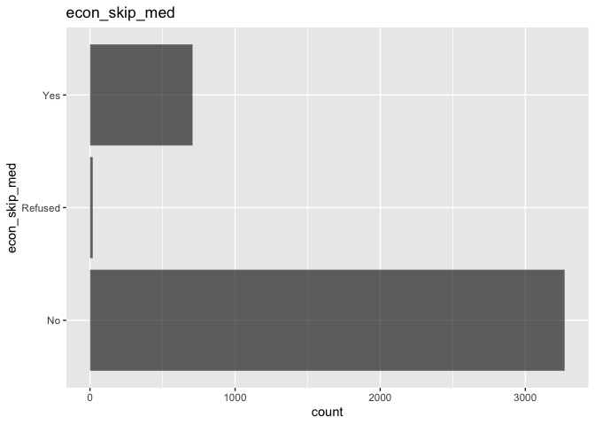

```r
# econ_skip_med
ggplot(fed_df, aes(x=econ_skip_med)) +
  geom_bar(color="white", fill="black", alpha = 0.6, size = 0.1) +
  coord_flip() +
  labs(title = "econ_skip_med")
```

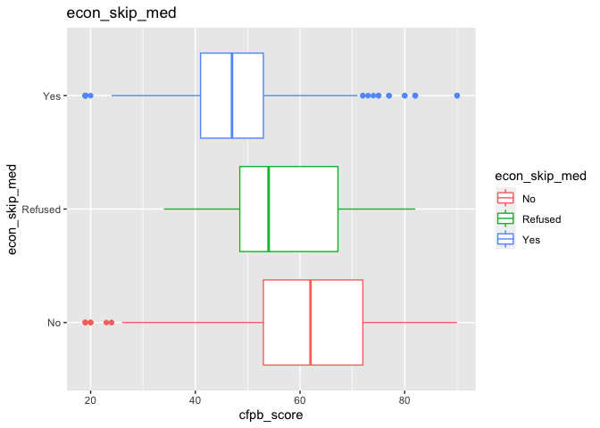

```r
ggplot(fed_df) +
  geom_boxplot(mapping = aes(x=cfpb_score, y=econ_skip_med, color=econ_skip_med)) +
  labs (title = "econ_skip_med")
```

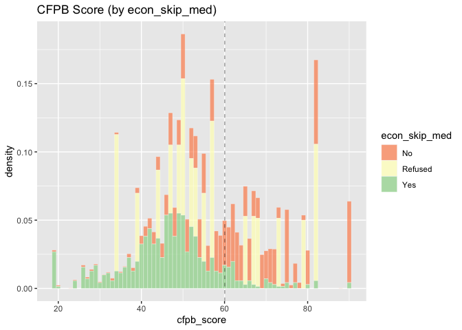

```r
ggplot(fed_df,
    aes(cfpb_score, fill = econ_skip_med, y = stat(density))) +
    geom_histogram(binwidth = 1, alpha = 0.7, bins = 100, color="white",size = 0.1) +
    geom_vline(aes(xintercept = mean(cfpb_score)), linetype = "dashed", size = 0.2) +
    scale_fill_brewer(palette="Spectral") +
    labs(title = "CFPB Score (by econ_skip_med)")
```

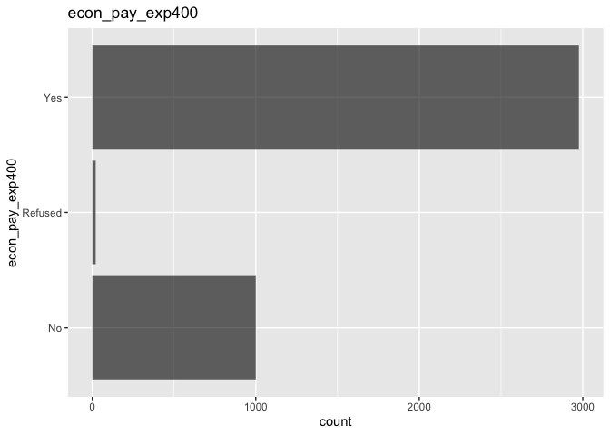

```r
# econ_pay_exp400
ggplot(fed_df, aes(x=econ_pay_exp400)) +
  geom_bar(color="white", fill="black", alpha = 0.6, size = 0.1) +
  coord_flip() +
  labs(title = "econ_pay_exp400")
```

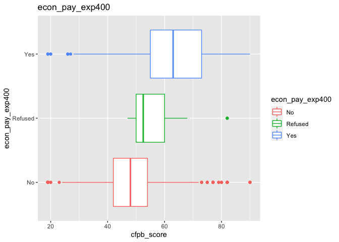

```r
ggplot(data = fed_df) +
  geom_boxplot(mapping = aes(x=cfpb_score, y=econ_pay_exp400, color=econ_pay_exp400)) +
  labs (title = "econ_pay_exp400")
```

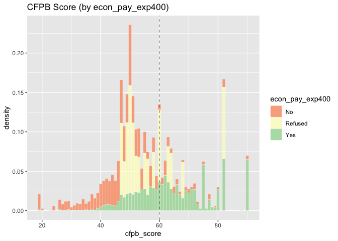

```r
ggplot(fed_df,
    aes(cfpb_score, fill = econ_pay_exp400, y = stat(density))) +
    geom_histogram(binwidth = 1, alpha = 0.7, bins = 100, color="white",size = 0.1) +
    geom_vline(aes(xintercept = mean(cfpb_score)), linetype = "dashed", size = 0.2) +
    scale_fill_brewer(palette="Spectral") +
    labs(title = "CFPB Score (by econ_pay_exp400)")
```

# Model

The analysis started with a simple linear model. As an extension of the variable exploration process backwards and forwards step elimination was used to identify the variables to include in the model. In depth analysis can be found in the DATA607_Explore.Rmd file.

## Consumer Financial Protection Bureau

cfpb_score econ_hh_income econ_save_rate age_8cat

```r
# select independent variables
cfpb_df <- cfpb_df %>% select(cfpb_score, econ_hh_income, econ_save_rate, age_8cat) # 0.3984


# split data
cfpb_split <- initial_split(cfpb_df, prop = 0.8, strata = cfpb_score)
cfpb_training <-  training(cfpb_split)
cfpb_test <-  testing(cfpb_split)
```

The model stats - r-squared for the model is 0.403 - The residual analysis analysis shows several outlines that are impacting the model

```r
# Model Specification
lm_model <- linear_reg() %>%
            set_engine('lm') %>%
            set_mode('regression')


# Fitting to Trained Data
lm_fit <- lm_model %>%
          fit(cfpb_score ~ ., data = cfpb_training)


# Explore Training Results
names(lm_fit)
```

```
## [1] "lvl"     "spec"    "fit"     "preproc" "elapsed"
```

```r
summary(lm_fit$fit)
```

```
##
## Call:
## stats::lm(formula = cfpb_score ~ ., data = data)
##
## Residuals:
##     Min      1Q  Median      3Q     Max
## -37.089  -6.642  -0.395   6.234  44.081
##
## Coefficients:
##                                    Estimate Std. Error t value Pr(>|t|)
## (Intercept)                        49.49708    2.85377  17.344  < 2e-16 ***
## econ_hh_income$20,000 to $29,999   -1.17388    0.94110  -1.247 0.212360
## econ_hh_income$30,000 to $39,999    1.17112    0.90278   1.297 0.194641
## econ_hh_income$40,000 to $49,999    2.53457    0.94833   2.673 0.007564 **
## econ_hh_income$50,000 to $59,999    3.58338    0.94931   3.775 0.000163 ***
## econ_hh_income$60,000 to $74,999    3.87421    0.90850   4.264 2.06e-05 ***
## econ_hh_income$75,000 to $99,999    5.10259    0.84088   6.068 1.45e-09 ***
## econ_hh_income$100,000 to $149,999  6.47794    0.83380   7.769 1.06e-14 ***
## econ_hh_income$150,000 or more      7.91585    0.87535   9.043  < 2e-16 ***
## econ_save_rate0                    -7.52775    2.82355  -2.666 0.007713 **
## econ_save_rate$1-99                -8.88012    2.83642  -3.131 0.001759 **
## econ_save_rate$100-999             -4.58662    2.77083  -1.655 0.097958 .
## econ_save_rate$1,000-4,999         -0.34825    2.75185  -0.127 0.899305
## econ_save_rate$5,000-19,999         4.56124    2.74443   1.662 0.096612 .
## econ_save_rate$20,000-74,999        8.25068    2.75656   2.993 0.002783 **
## econ_save_rate$75,000 or more      11.16216    2.75797   4.047 5.31e-05 ***
## econ_save_rateI don't know         -0.63470    2.94091  -0.216 0.829144
## econ_save_ratePrefer not to say     4.87554    2.74531   1.776 0.075837 .
## age_8cat25-34                      -0.30324    0.88055  -0.344 0.730591
## age_8cat35-44                      -0.34872    0.93268  -0.374 0.708511
## age_8cat45-54                      -1.22148    0.89034  -1.372 0.170182
## age_8cat55-61                       0.02912    0.93394   0.031 0.975128
## age_8cat62-69                       4.55598    0.89471   5.092 3.75e-07 ***
## age_8cat70-74                       6.31120    1.00534   6.278 3.90e-10 ***
## age_8cat75+                         7.10285    0.94818   7.491 8.81e-14 ***
## ---
## Signif. codes:  0 '***' 0.001 '**' 0.01 '*' 0.05 '.' 0.1 ' ' 1
##
## Residual standard error: 10.45 on 3174 degrees of freedom
## Multiple R-squared:  0.4071, Adjusted R-squared:  0.4026
## F-statistic: 90.79 on 24 and 3174 DF,  p-value: < 2.2e-16
```

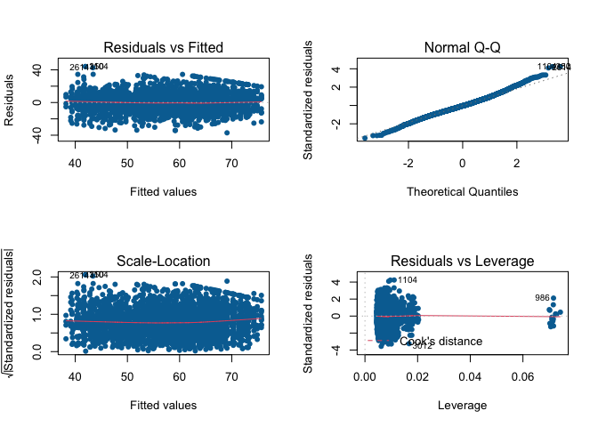

```r
par(mfrow=c(2,2))
plot(lm_fit$fit, pch = 16, col = '#006EA1')
```

```r
# Data frame of estimated coefficients
tidy(lm_fit)
```

```
## # A tibble: 25 × 5
##    term                               estimate std.error statistic  p.value
##    <chr>                                 <dbl>     <dbl>     <dbl>    <dbl>
##  1 (Intercept)                           49.5      2.85      17.3  1.86e-64
##  2 econ_hh_income$20,000 to $29,999      -1.17     0.941     -1.25 2.12e- 1
##  3 econ_hh_income$30,000 to $39,999       1.17     0.903      1.30 1.95e- 1
##  4 econ_hh_income$40,000 to $49,999       2.53     0.948      2.67 7.56e- 3
##  5 econ_hh_income$50,000 to $59,999       3.58     0.949      3.77 1.63e- 4
##  6 econ_hh_income$60,000 to $74,999       3.87     0.908      4.26 2.06e- 5
##  7 econ_hh_income$75,000 to $99,999       5.10     0.841      6.07 1.45e- 9
##  8 econ_hh_income$100,000 to $149,999     6.48     0.834      7.77 1.06e-14
##  9 econ_hh_income$150,000 or more         7.92     0.875      9.04 2.59e-19
## 10 econ_save_rate0                       -7.53     2.82      -2.67 7.71e- 3
## # … with 15 more rows
```

```r
# Performance metrics on training data
glance(lm_fit)
```

```
## # A tibble: 1 × 12
##   r.squared adj.r.squared sigma statistic p.value    df  logLik    AIC    BIC
##       <dbl>         <dbl> <dbl>     <dbl>   <dbl> <dbl>   <dbl>  <dbl>  <dbl>
## 1     0.407         0.403  10.5      90.8       0    24 -12034. 24119. 24277.
## # … with 3 more variables: deviance <dbl>, df.residual <int>, nobs <int>
```

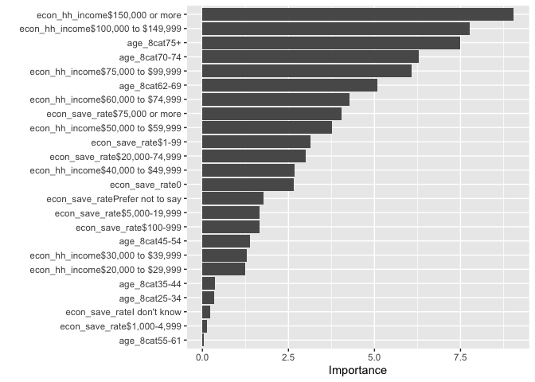

```r
# variable importance
vip(lm_fit, num_features=25)
```

```r
#predict(lm_fit, new_data = cfpb_test)

cfpb_results <- predict(lm_fit, new_data = cfpb_test) %>%
                            bind_cols(cfpb_test)

#cfpb_results

# RMSE on test set
rmse(cfpb_results, truth = cfpb_score, estimate = .pred)
```

```
## # A tibble: 1 × 3
##   .metric .estimator .estimate
##   <chr>   <chr>          <dbl>
## 1 rmse    standard        10.7
```

```r
rsq(cfpb_results, truth = cfpb_score, estimate = .pred)
```

```
## # A tibble: 1 × 3
##   .metric .estimator .estimate
##   <chr>   <chr>          <dbl>
## 1 rsq     standard       0.421
```

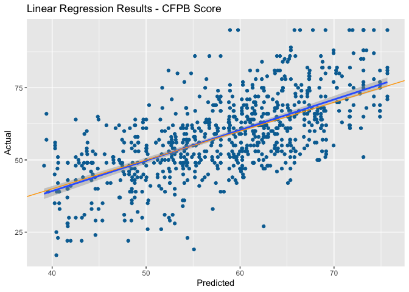

```r
ggplot(data = cfpb_results,
       mapping = aes(x = .pred, y = cfpb_score)) +
  geom_point(color = '#006EA1') +
  geom_smooth(method = lm) +
  geom_abline(intercept = 0, slope = 1, color = 'orange') +
  labs(title = 'Linear Regression Results - CFPB Score',
       x = 'Predicted',
       y = 'Actual')
```